# Gross Revenue Prediction using Liner Regression

## 1. Objective

Objective of this project is to help a studio in priortization (such as decide which titles to fund for production, how much to bid on produced movies, when to release a title, how much to invest in marketing and PR, etc.) by investigating the relationship between the movie descriptors and the success of the movie at box office which is represented as Gross Revenue. This analysis is very valuable after the movie is already released as it can affect additional marketing spend or how much a studio should negotiate with on-demand streaming companies etc.

## 2. About Dataset

Dataset has 40K rows and 39 columns which contains information about movies, including ratings, budget, gross revenue and other attributes. It was prepared by by querying IMDb’s API (see www.omdbapi.com) and joining it with a separate dataset of movie budgets and gross earnings (unknown to you). The join key was the movie title. Each row represents a movie title and each column represents a descriptor such as Title, Actors, and Budget.

## 3. Data Anlaysis

```r
# Load Dataset
load('movies_merged')
df = movies_merged
cat("Rows: ", dim(df)[1], end="\n")
```

```
## Rows:  40789
```

```r
cat("Columns: ", dim(df)[2], end="\n")
```

```
## Columns:  39
```

```r
cat("Column names:", end="\n")
```

```
## Column names:
```

```r
colnames(df)
```

```
##  [1] "Title"             "Year"              "Rated"
##  [4] "Released"          "Runtime"           "Genre"
##  [7] "Director"          "Writer"            "Actors"
## [10] "Plot"              "Language"          "Country"
## [13] "Awards"            "Poster"            "Metascore"
## [16] "imdbRating"        "imdbVotes"         "imdbID"
## [19] "Type"              "tomatoMeter"       "tomatoImage"
## [22] "tomatoRating"      "tomatoReviews"     "tomatoFresh"
## [25] "tomatoRotten"      "tomatoConsensus"   "tomatoUserMeter"
## [28] "tomatoUserRating"  "tomatoUserReviews" "tomatoURL"
## [31] "DVD"               "BoxOffice"         "Production"
## [34] "Website"           "Response"          "Budget"
## [37] "Domestic_Gross"    "Gross"             "Date"
```

```r
# Load R packages
library(ggplot2)
library(GGally)
library(dplyr)
library(stringr)
library(data.table)
library(PerformanceAnalytics)
library(ggpubr)
library(tm)
library(reshape2)
library(gridExtra)
```

### 3.1 Data Analysis: Relationship between Year, Runtime and Budget

```r
#Removing non-movie rows from dataset using dplyr filter method
df2 <- df[df$Type == "movie",]

#Column Runtime in the dataset represents the length of the title as a string. Converting movie runtime value (in minutes) to numerical value.
df2$Runtime <- gsub(" min", "", df2$Runtime)
df2$Runtime <- gsub(" h ", "", df2$Runtime)
df2$Runtime <- gsub(" h", "", df2$Runtime)
df2$Runtime <- as.numeric(as.character(df2$Runtime))

#Investigating the distribution of `Runtime` values and how it changes over years.

#Bucketing the years into decades
decade <- (as.integer(df2$Year/10))*10
df2 <- cbind(df2, decade)

#Converting unit of Budget to Millions
df2$Budget <- df2$Budget/1000000
df2$Gross <- df2$Gross/1000000
```

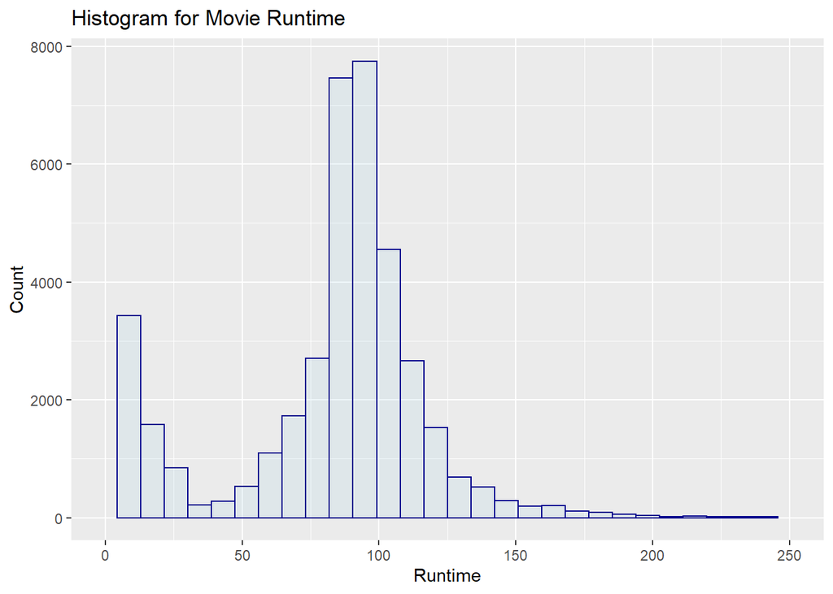

```r
#Distrubution of Runtime
ggplot(data=df2, aes(x=df2$Runtime)) + geom_histogram(color="darkblue", fill="lightblue", alpha = .2) +
  labs(title="Histogram for Movie Runtime", x="Runtime", y="Count") + xlim(c(0,250))
```

This histogram plot shows the distribution of the Runtime. It can be observed that Runtime can be categorized into two distinct groups:

- Movies with Runtime < 45 minutes
- Movies with Runtime > 45 mintues.

Possible reason for the two groupings is that there are “Short Films” with shorter Runtime and full lenght “Theatrical Films” It can also be noted that the most frequently occuring Runtime across all movies is 90 minutes.

The Runtime distribution is bi-modal with a right skew and a very long tail indicates outliers.

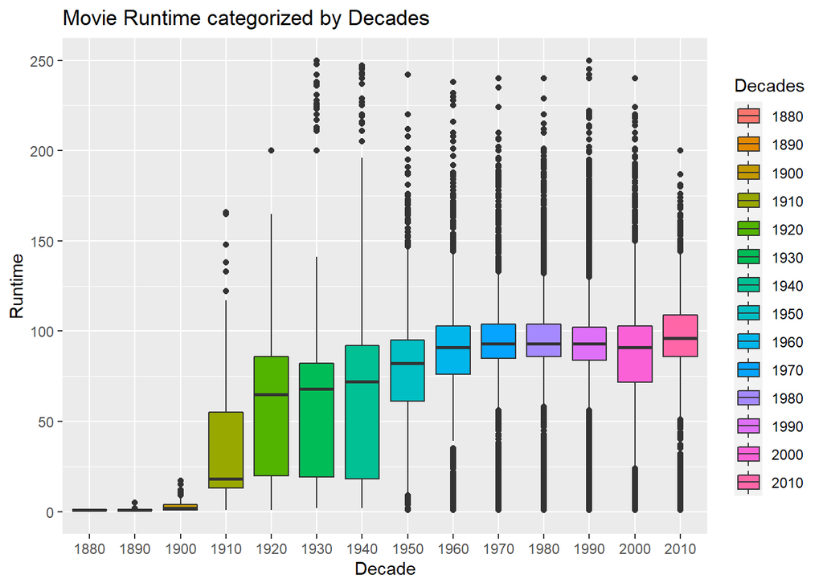

```r
#Distribution of Runtime over decades
ggplot(df2,aes(y=df2$Runtime,x=factor(decade),
               fill=factor(decade)))+geom_boxplot()+ylab("Runtime")+xlab("Decade")+ylim(0,250)+
  labs(fill="Decades")+ggtitle("Movie Runtime categorized by Decades")
```

In the 1880s movies were relatively very short with a Runtime length of less that 5 minute. The Box plot demonstrate that as the decades have passed there is gradual increase in the runtime median.

Until the end of 1910s century the movie runtimes is below 20 minutes. Beginning 20th century, as new technologies were invented and media got popularized we can see a descent raise in the runtimes.

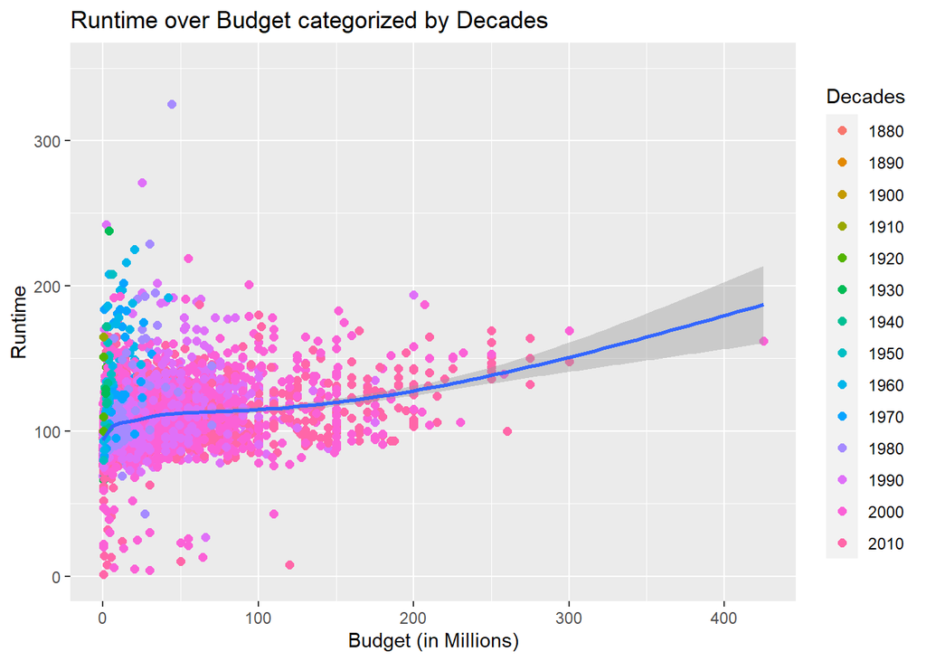

```r
#Distribution of Runtime over Budget
ggplot(df2, aes(x=Budget, y=Runtime))+geom_point(aes(color = factor(df2$decade)), size = 2)+
  labs(color="Decades")+xlab("Budget (in Millions)")+ylab("Runtime")+coord_cartesian(ylim=c(0,350))+ geom_smooth()+
  ggtitle("Runtime over Budget categorized by Decades")
```

Scatter depicts the relationship between runtime and budget. From this plot we can see that maximum of the movies in the dataset are of ‘Regular’ runtime i.e. around 100 minutes irrespective of the budget. There is a positive corelation between Budget and Runtime. It is evident accumulated around runtime value of 90-100 minutes.

### 3.2 Data Analysis: Popular Genres

The column `Genre` represents a list of genres associated with the movie in a string format. Below code parses each text string into a binary vector with 1s representing the presence of a genre and 0s the absence and add it to the dataframe as additional columns. Code removes the original `Genre` column.

For example, if there are a total of 3 genres: Drama, Comedy, and Action, a movie that is both Action and Comedy should be represented by a binary vector <0, 1, 1>.

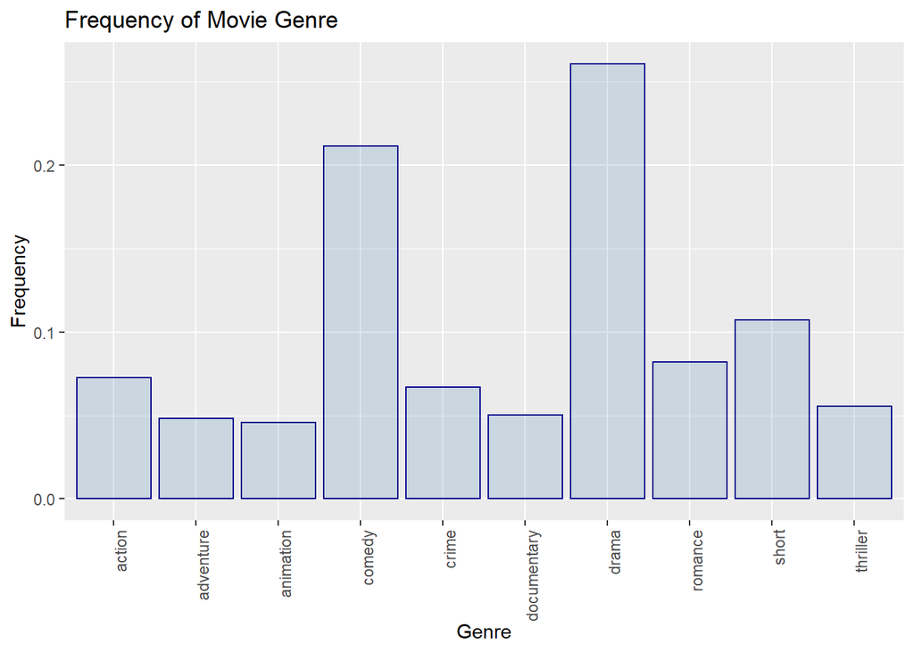

```r
genreCorpus = Corpus(VectorSource(df2$Genre))
genreCorpus = tm_map(genreCorpus, content_transformer(tolower))
genreCorpus = tm_map(genreCorpus, removeWords, c("N/A"))
genreCorpus = tm_map(genreCorpus, removePunctuation)

genreDocumentTermMatrix = DocumentTermMatrix(genreCorpus)
genreMatrix = as.data.frame(as.matrix(genreDocumentTermMatrix))
df2 <- cbind(df2, genreMatrix)


# Plot the relative proportions of movies having the top 10 most common genres.


# Select movies from top 10 most common genres and plot their relative proportions
top10 <- (sort(colSums(genreMatrix), decreasing = TRUE)[1:10])
top10names <- names(sort(colSums(genreMatrix), decreasing = TRUE)[1:10])
dfTop10 <- data.frame(top10names, top10)

genreFreq <- colSums(as.matrix(genreDocumentTermMatrix))
genreFreqSort <- sort(genreFreq,decreasing = TRUE)[1:10]

dfGFreq <- data.frame(names(genreFreqSort), genreFreqSort/sum(genreFreqSort))
names(dfGFreq) = c("Genre","Frequency")

ggplot(data=dfGFreq, aes(x=dfGFreq$Genre)) +
  geom_histogram( aes(y=dfGFreq$Frequency), stat = "identity", color="darkblue", fill="steelblue"
                  , alpha = .2) +
  labs(title="Frequency of Movie Genre", x="Genre", y="Frequency") +
  theme(axis.text.x = element_text(angle = 90, hjust = 1))
```

From the above distribution plot, it is very clear that the top genres with highest proportions are Comedy and Drama which is liked by majority of the population. In addition to these 2 genres, short, action and romance movies have considerably high proportions compared to the rest of the movie genres.

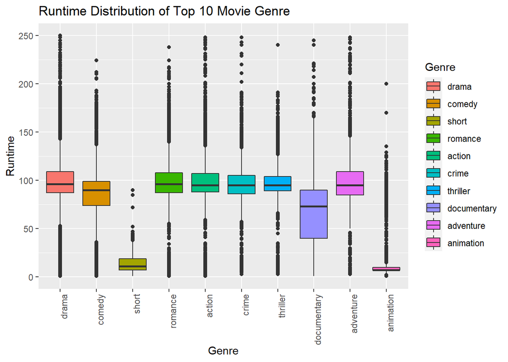

```r
# Plot Runtime distribution for top 10 most common genres

dfrun <- df2[,c("Runtime",top10names)]
dfrun <- melt(dfrun, id.vars = "Runtime", measure.vars = c(top10names))

dfrun <- dfrun[dfrun$value == 1,]

ggplot(dfrun, aes(factor(variable), Runtime,  fill=factor((variable)))) + geom_boxplot()+
  labs(title="Runtime Distribution of Top 10 Movie Genre", x="Genre", y="Runtime") +
  theme(axis.text.x = element_text(angle = 90, hjust = 1))+ ylim(0, 250)+labs(fill="Genre")
```

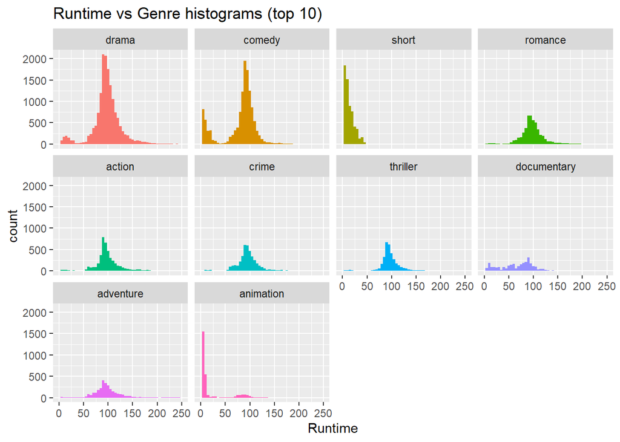

```r
ggplot(dfrun) + geom_histogram(mapping=aes(x=Runtime,fill=factor(variable)), binwidth=5) + facet_wrap(~factor(variable)) + xlim(0,250) + theme(legend.position = "false") + labs(title="Runtime vs Genre histograms (top 10)")
```

### 3.3 Data Analysis: Eliminate mismatched rows

The dataframe was put together by merging two different sources of data and it is possible that the merging process was inaccurate in some cases (the merge was done based on movie title, but there are cases of different movies with the same title). There are 3 columns that contain date information: `Year` (numeric year), `Date` (numeric year), and `Released` (string representation of the release date).

Below code finds and removes all rows where merge error might have occurred based on a mismatch between these variables. To make sure subsequent analysis and modeling work well, code avoids removing more than 10% of the rows that have a `Gross` value present.

```r
# Remove rows with Year/Date/Released mismatch
check <-function(Year, Date, ReleasedYear){

  if((is.na(Year) && is.na(Date) && is.na(ReleasedYear)) ||
     (is.na(Year) && is.na(Date)) ||
     (is.na(Date) && is.na(ReleasedYear)) ||
     (is.na(Year) && is.na(ReleasedYear))
  ){
    return(TRUE)

  }else if(is.na(Year) && !(is.na(Date)) && !(is.na(ReleasedYear))){
    if(Date == ReleasedYear){
      return(TRUE)

    }else{
      return(FALSE)
    }
  }else if(!(is.na(Year)) && is.na(Date) && !(is.na(ReleasedYear))){
    if(Year == ReleasedYear){
      return(TRUE)

    }else{
      return(FALSE)
    }
  }else if(!(is.na(Year)) && !(is.na(Date)) && is.na(ReleasedYear)){
    if(Date == Year){
      return(TRUE)

    }else{
      return(FALSE)
    }
  }else{
    if((Date == Year) || (Year == ReleasedYear) || (Date == ReleasedYear)){
      return(TRUE)
    }else{
      return(FALSE)
    }
  }

}

dfYear <- df2[mapply(check, as.numeric(df2$Year), as.numeric(df2$Date),
                     as.numeric(format(as.Date(df2$Released, format="%Y-%m-%d"),"%Y"))),]
cat("Remaining Record Count: ", as.character(nrow(dfYear)))
```

```
## Remaining Record Count:  34972
```

- If all 3 values are NA then return TRUE
- If 2 values are NA then reurn TRUE
- If one value is NA then check Year in other two values. If both Years are same return True else False.
- If none of the values are NA, then check Year for all three values. If any two Years are same return True else False.

### 3.4 Data Analysis: Gross Revenue

For the commercial success of a movie, production houses want to maximize Gross revenue. Next I investigate if Gross revenue is related to Budget, Runtime or Genre in any way.

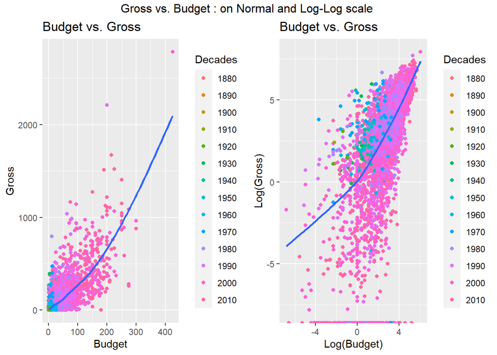

```r
# Investigate if Gross Revenue is related to Budget, Runtime or Genre

p1 <- ggplot(dfYear, aes(Budget, Gross)) + geom_point(aes(color = factor(dfYear$decade)))+
  ggtitle("Budget vs. Gross")+ylab("Gross")+
  xlab("Budget")+labs(color="Decades") + geom_smooth(se=F)

p2 <- ggplot(dfYear, aes(log(Budget), log(Gross))) + geom_point(aes(color = factor(dfYear$decade)))+
  ggtitle("Budget vs. Gross")+ylab("Log(Gross)")+
  xlab("Log(Budget)")+labs(color="Decades") + geom_smooth(se=F)

grid.arrange(p1, p2, ncol=2, top ="Gross vs. Budget : on Normal and Log-Log scale " )
```

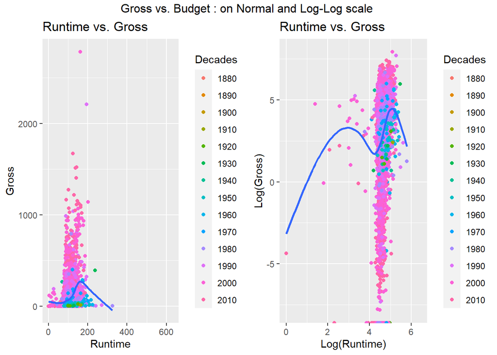

```r
p1 <- ggplot(dfYear, aes(Runtime, Gross)) + geom_point(aes(color = factor(dfYear$decade)))+
  ggtitle("Runtime vs. Gross")+ylab("Gross")+
  xlab("Runtime")+labs(color="Decades") + geom_smooth(se=F)

p2 <- ggplot(dfYear, aes(log(Runtime), log(Gross))) + geom_point(aes(color = factor(dfYear$decade)))+
  ggtitle("Runtime vs. Gross")+ylab("Log(Gross)")+
  xlab("Log(Runtime)")+labs(color="Decades") + geom_smooth(se=F)

grid.arrange(p1, p2, ncol=2, top ="Gross vs. Budget : on Normal and Log-Log scale " )
```

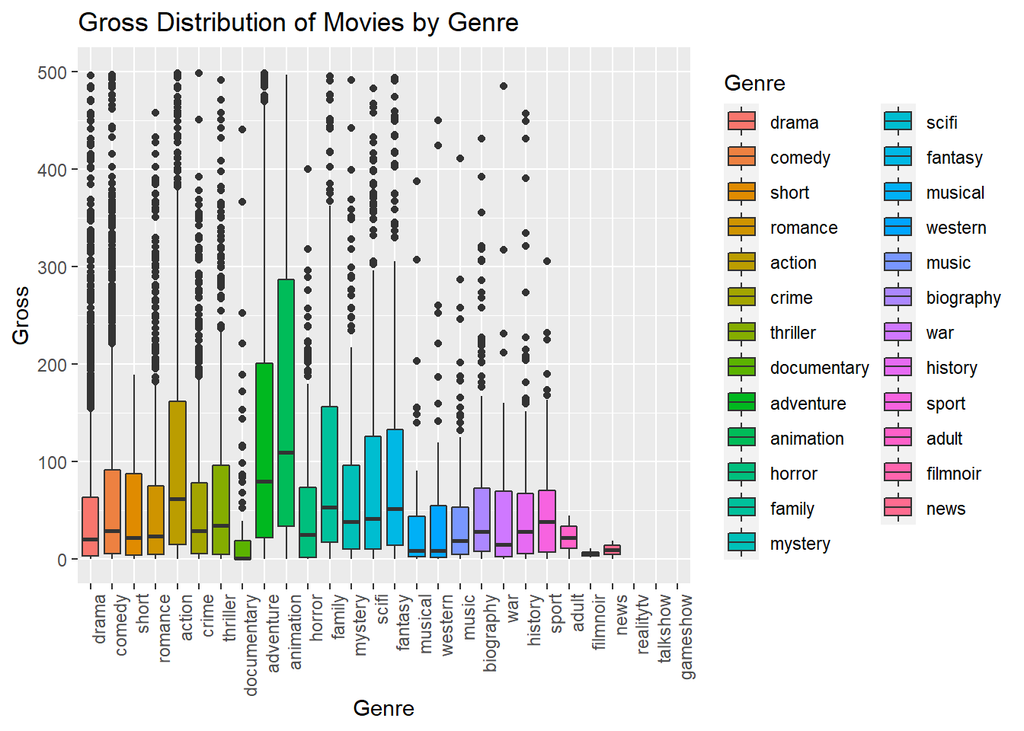

```r
mduration <- factor(ifelse(df2$Runtime<=25, "Short", ifelse((df2$Runtime>25) & (df2$Runtime<=75) ,
                                                            "Medium", ifelse((df2$Runtime>75) & (df2$Runtime<=150) , "Long", "VeryLong"))))

dfdur <- cbind(mduration, df2)
dfdur$mduration <- as.factor(dfdur$mduration)

gnames <- names(sort(colSums(genreMatrix), decreasing = TRUE))
dfGrossGenre <- dfYear[,c("Gross",gnames)]
dfGrossGenre <- melt(dfGrossGenre, id.vars = "Gross", measure.vars = c(gnames))

dfGrossGenre <- dfGrossGenre[dfGrossGenre$value == 1,]

ggplot(dfGrossGenre, aes(factor(variable), Gross,  fill=factor((variable)))) +
  geom_boxplot()+labs(title="Gross Distribution of Movies by Genre", x="Genre", y="Gross") +
  theme(axis.text.x = element_text(angle = 90, hjust = 1))+ ylim(0, 500)+labs(fill="Genre")
```

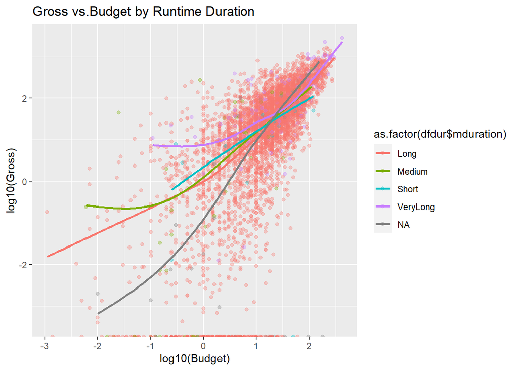

```r
ggplot(dfdur, aes(x=log10(Budget), y=log10(Gross),color=as.factor(dfdur$mduration))) + geom_point(alpha=1/3 ) + ggtitle("Gross vs.Budget by Runtime Duration") + geom_smooth(se=F)
```

Gross vs. Runtime plot shows a weaker relationship between gross revenue and runtime.Gross increases with Runtime only to a certain extent.

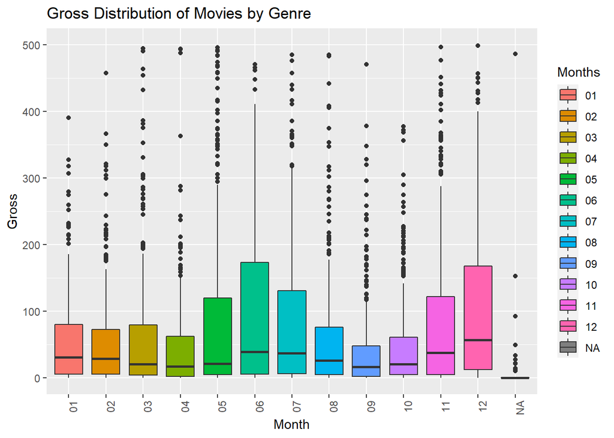

```r
# Investigate if Gross Revenue is related to Release Month
dmonth <- data.frame(do.call('rbind', strsplit(as.character(df2$Released),'-',fixed=TRUE)))[,2]
dfmonth <- cbind(dmonth, df2)

ggplot(dfmonth, aes(factor(dmonth), Gross,  fill=factor((dmonth)))) +
  geom_boxplot()+labs(title="Gross Distribution of Movies by Genre", x="Month", y="Gross") +
  theme(axis.text.x = element_text(angle = 90, hjust = 1))+
  ylim(0, 500)+labs(fill="Months")
```

### 3.5 Data Analysis: Awards

The column Awards describes nominations and awards in text format. Below code converts it to 2 numeric columns, the first capturing the number of wins, and the second capturing nominations. Code replaces the Awards column with these new columns and then study the relationship of Gross revenue with respect to them.

```r
# Convert Awards to 2 numeric columns: wins and nominations
dfAwNom <- data.frame()
for(i in seq(length(df2$Awards))){
  wins = 0
  nomi = 0

  string <- strsplit(df2$Awards[i], split="[.&]")
  for (sent in string[[1]]) {
    if (grepl("win", tolower(sent)) || grepl("won", tolower(sent))){
      wins = wins + as.numeric(gsub("[[:alpha:]]", "", sent))
    }else if(grepl("nominat", tolower(sent))){
      nomi = nomi + as.numeric(gsub("[[:alpha:]]", "", sent))
    }
  }

  dfAwNom <- rbind(dfAwNom,c(wins,wins+nomi))
}

dfAwNom <- cbind(df2$Gross, dfAwNom)
colnames(dfAwNom)<-c("Gross", "Wins","Nominations")

cat("Record Count with Valid wins/nominations: ", as.character(nrow(dfAwNom[(dfAwNom$Nominations>0),])))
```

```
## Record Count with Valid wins/nominations:  14727
```

Following strategy was used to capture wins and nominations -

- Initailize win and nominate variables to 0
- Loop through each row and get string from “Awards” column.
- Split string using either . or &
- Convert each substring to lowercase
- If substring has “win/won”, remove all alphbets and increament wins variable by digits in remaining string
- If substring has “nominat”, remove all alphbets and increament nominate variable by digits in remaining string

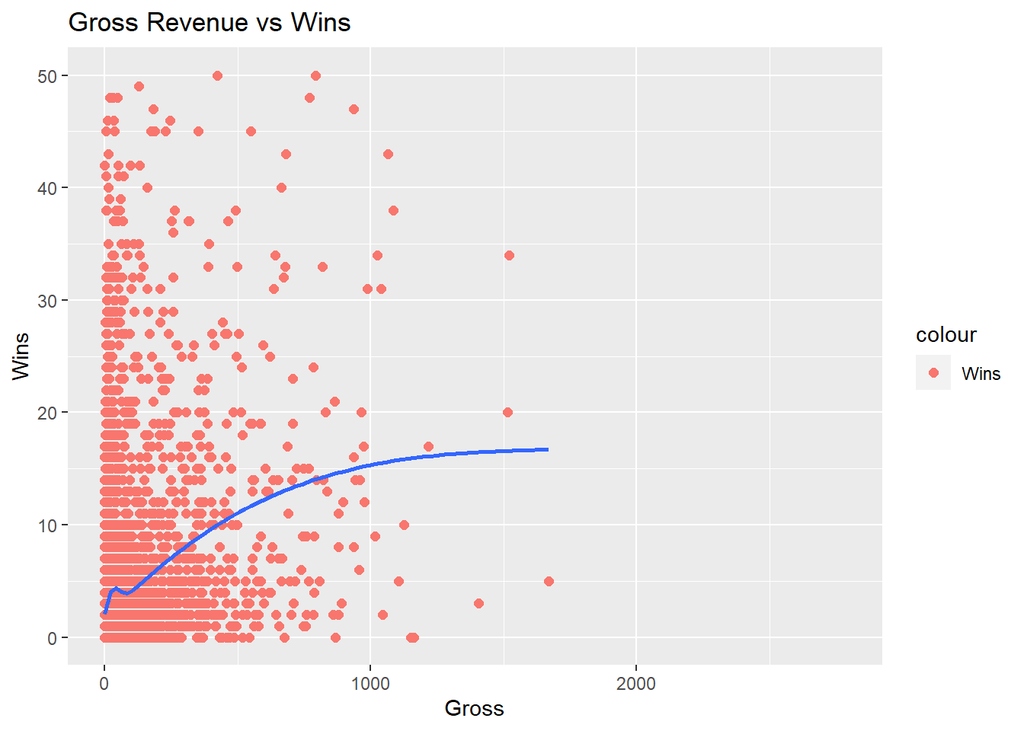

```r
# Plot Gross revenue against wins and nominations

dfAwNom <- dfAwNom[!is.na(dfAwNom$Gross),]

ggplot(dfAwNom, aes(x=dfAwNom$Gross, y=dfAwNom$Wins)) + geom_point(aes(y=dfAwNom$Wins, color="Wins"), size = 2)+ geom_smooth(se=F) + labs(title="Gross Revenue vs Wins", x="Gross", y="Wins")+ ylim(0, 50)
```

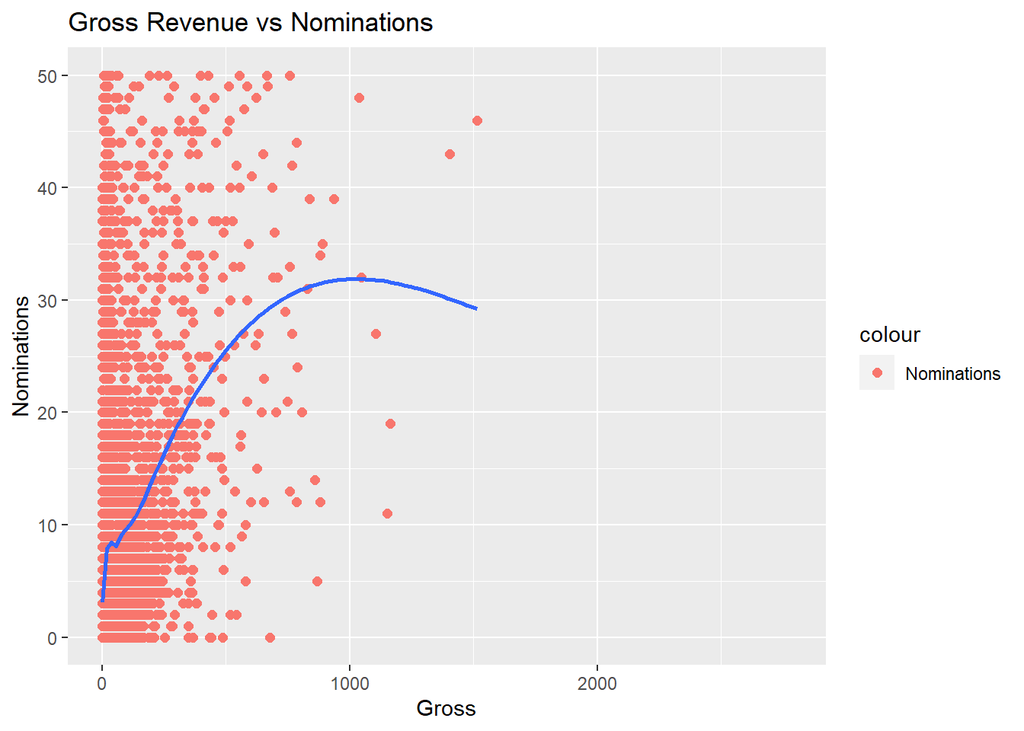

```r
ggplot(dfAwNom, aes(x=dfAwNom$Gross, y=dfAwNom$Nominations)) + geom_point(aes(y=dfAwNom$Nominations, color="Nominations"), size = 2)+ geom_smooth(se=F) + labs(title="Gross Revenue vs Nominations", x="Gross", y="Nominations")+ ylim(0, 50)
```

From the above scatter plot, we can see both Wins and Nominations seem to have slightly positive correlation with gross revenue. Gross Revenue tends to increase with number of wins and nominations received but after a certain number of awards (>25 or so) slope of this relationship becomes less steep.

### 3.6 Data Analysis: Rating

There are several variables that describe ratings, including IMDb ratings (`imdbRating` represents average user ratings and `imdbVotes` represents the number of user ratings), and multiple Rotten Tomatoes ratings (represented by several variables pre-fixed by `tomato`). Below code investigates the pairwise relationships between these different descriptors using plots.

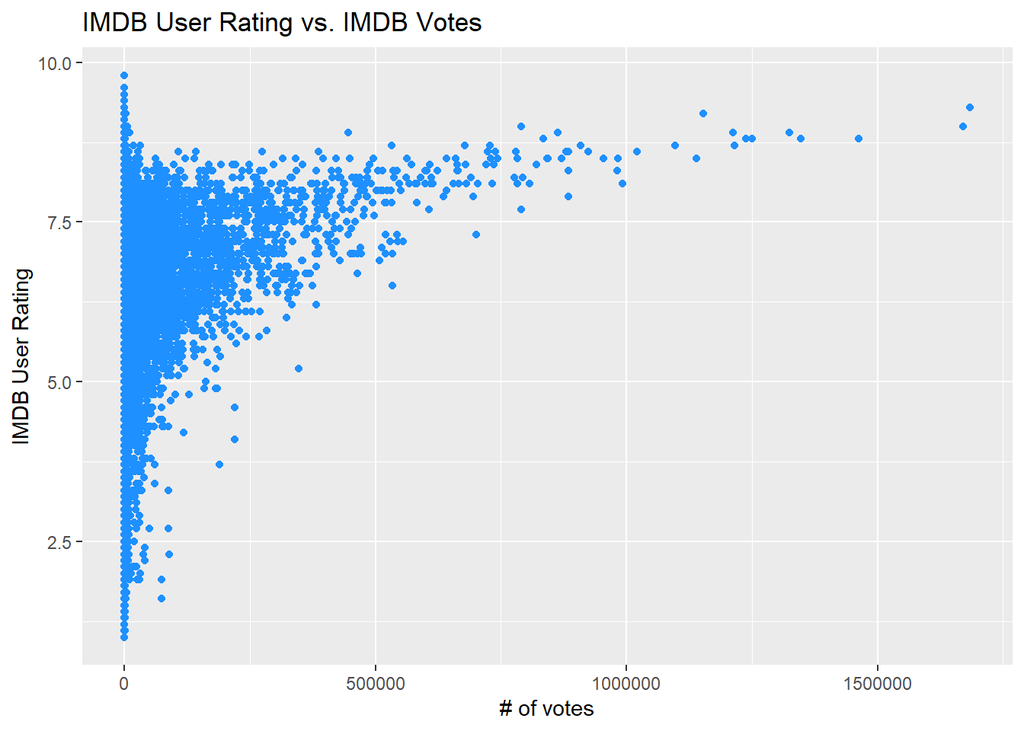

```r
# Illustrate how ratings from IMDb and Rotten Tomatoes are related

ggplot(subset(df2, !is.na(imdbVotes) & !is.na(imdbRating)), aes(x = imdbVotes, y = imdbRating)) + geom_point(color="dodgerblue") + labs(title = "IMDB User Rating vs. IMDB Votes", x = "# of votes", y = "IMDB User Rating")
```

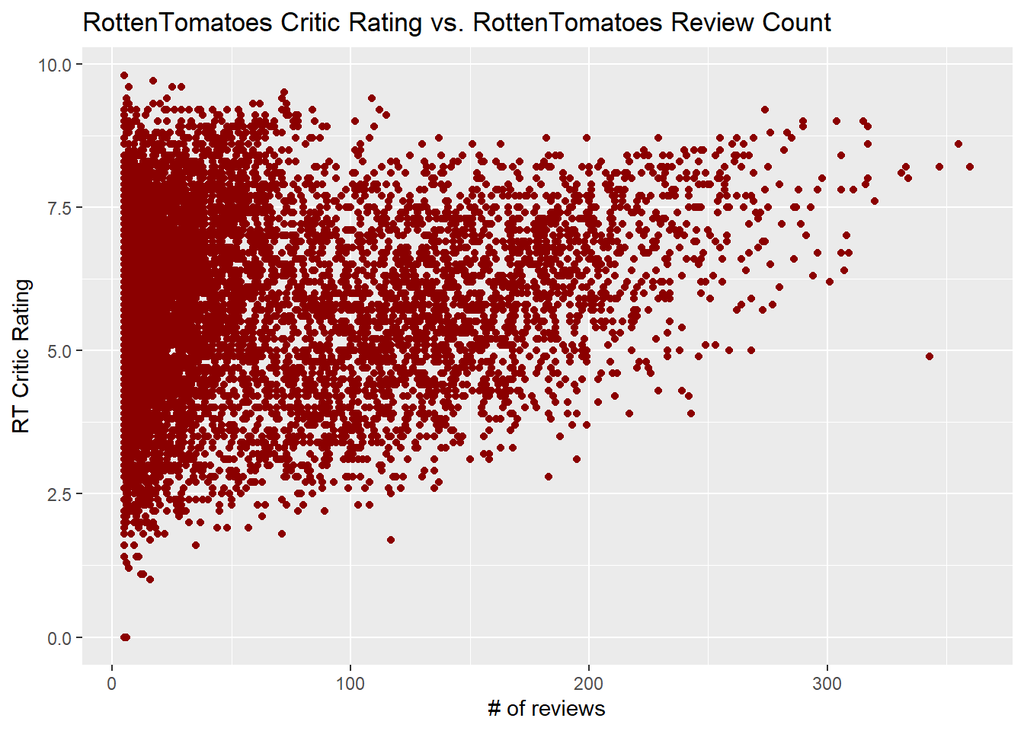

```r
ggplot(subset(df2, !is.na(tomatoReviews) & !is.na(tomatoRating)), aes(x = tomatoReviews, y = tomatoRating))+ geom_point(color="darkred") + labs(title = "RottenTomatoes Critic Rating vs. RottenTomatoes Review Count", x = "# of reviews", y = "RT Critic Rating")
```

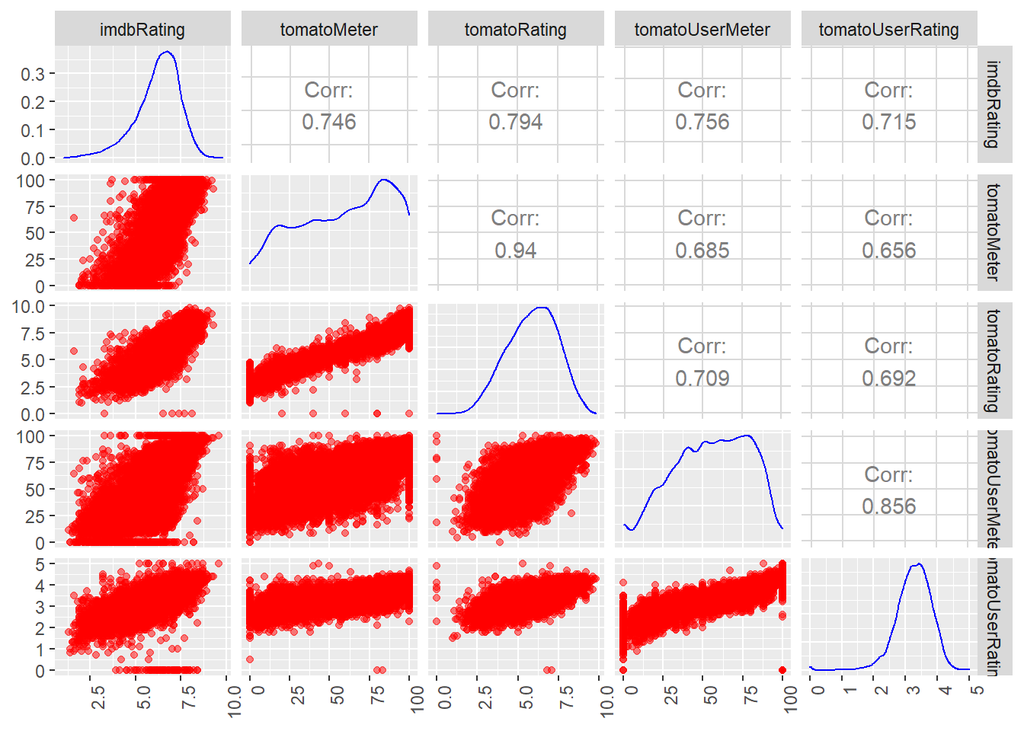

```r
ratingcols = c("imdbRating", "tomatoMeter","tomatoRating", "tomatoUserMeter","tomatoUserRating")

ggpairs(df2, lower = list(continuous = wrap("points", color = "red", alpha = 0.5),
                          combo = wrap("box", color = "orange", alpha = 0.3),
                          discrete = wrap("facetbar", color = "yellow", alpha = 0.3) ),
        diag = list(continuous = wrap("densityDiag",  color = "blue", alpha = 0.5) ),
        ratingcols)+
  theme(axis.text.x = element_text(angle = 90, hjust = 1))
```

Due to positive correlations between IMDB and Rotten Tomatoes plots it can be cloncluded that there is a general consensus about how movies are rated. Each pairwise graph shows a fairly broad line, though, so there is still a good amount of variability present.

There is also a conspicuous line along the x-axis of the imdbRating vs. tomatoUserRating graph, possibly indicating review bombing from upset users. The other two graphs relating review count to rating show an interesting, but understandble trend: IMDB ratings are more closely related to number of IMDB reviews than RT Critic ratings are to number of RT Critic reviews.

This is likely because IMDB users are more likely to self-select movies they think they will enjoy, while the job of a critic is to watch a wide variety of movies and remain as unbiased as possible.

### 3.7 Data Analysis: Rating vs Awards

These ratings typically reflect the general appeal of the movie to the public or gather opinions from a larger body of critics. Whereas awards are given by professional societies that may evaluate a movie on specific attributes, such as artistic performance, screenplay, sound design, etc. Below code study the relationship between ratings and awards using graphs (awards here refers to wins and/or nominations).

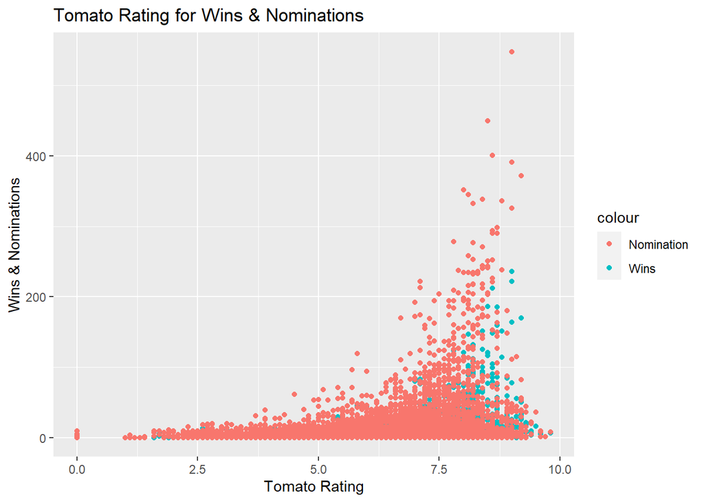

```r
# Show how ratings and awards are related
dfRateAwNom <- data.frame()
for(i in seq(length(df2$Awards))){
  wins = 0
  nomi = 0

  string <- strsplit(df2$Awards[i], split="[.&]")
  for (sent in string[[1]]) {
    if (grepl("win", tolower(sent)) || grepl("won", tolower(sent))){
      wins = wins + as.numeric(gsub("[[:alpha:]]", "", sent))
    }else if(grepl("nominat", tolower(sent))){
      nomi = nomi + as.numeric(gsub("[[:alpha:]]", "", sent))
    }
  }

  dfRateAwNom <- rbind(dfRateAwNom,c(wins,wins+nomi))
}

dfRateAwNom <- cbind(df2$tomatoRating, df2$tomatoUserRating, df2$imdbRating, df2$imdbVotes, dfRateAwNom)
colnames(dfRateAwNom)<-c("TomatoRating", "TomatoUserRating", "ImdbRating", "ImdbVotes",
                         "Wins","Nominations")

ggplot(dfRateAwNom, aes(dfRateAwNom$TomatoRating)) +
  geom_point(data=dfRateAwNom, aes(y=dfRateAwNom$Wins, color="Wins")) +
  geom_point(data=dfRateAwNom, aes(y=dfRateAwNom$Nominations, color="Nomination")) +
  labs(title="Tomato Rating for Wins & Nominations", x="Tomato Rating", y="Wins & Nominations")
```

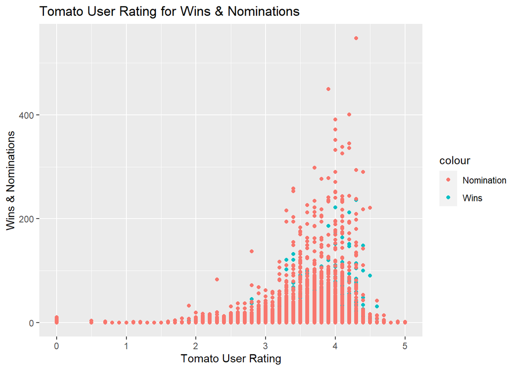

```r
ggplot(dfRateAwNom, aes(dfRateAwNom$TomatoUserRating)) +
  geom_point(data=dfRateAwNom, aes(y=dfRateAwNom$Wins, color="Wins")) +
  geom_point(data=dfRateAwNom, aes(y=dfRateAwNom$Nominations, color="Nomination")) +
  labs(title="Tomato User Rating for Wins & Nominations", x="Tomato User Rating", y="Wins & Nominations")
```

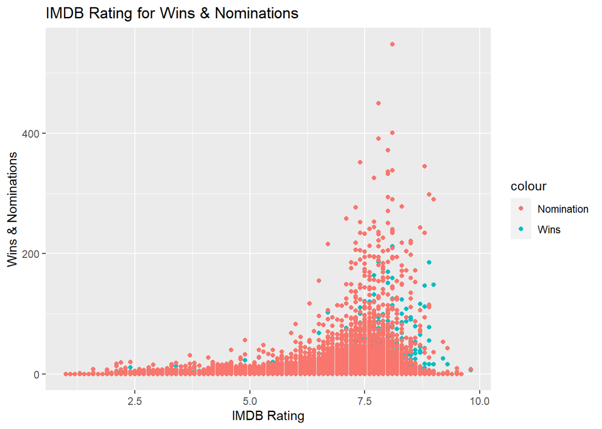

```r
ggplot(dfRateAwNom, aes(dfRateAwNom$ImdbRating)) +
  geom_point(data=dfRateAwNom, aes(y=dfRateAwNom$Wins, color="Wins")) +
  geom_point(data=dfRateAwNom, aes(y=dfRateAwNom$Nominations, color="Nomination")) +
  labs(title="IMDB Rating for Wins & Nominations", x="IMDB Rating", y="Wins & Nominations")
```

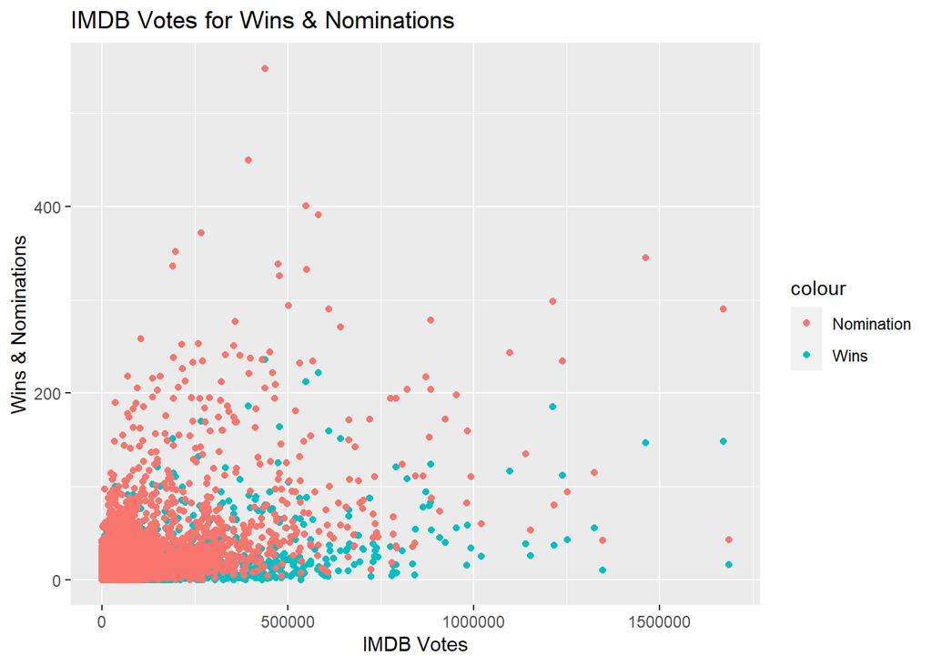

```r
ggplot(dfRateAwNom, aes(dfRateAwNom$ImdbVotes)) +
  geom_point(data=dfRateAwNom, aes(y=dfRateAwNom$Wins, color="Wins")) +
  geom_point(data=dfRateAwNom, aes(y=dfRateAwNom$Nominations, color="Nomination")) +
  labs(title="IMDB Votes for Wins & Nominations", x="IMDB Votes", y="Wins & Nominations")
```

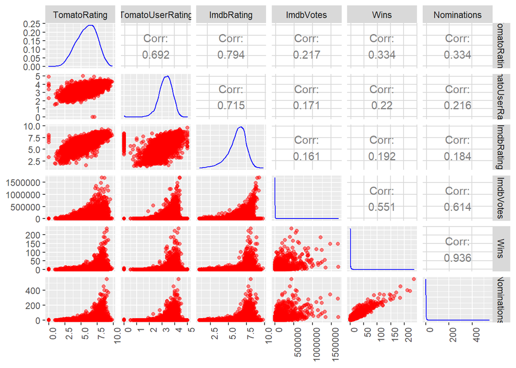

```r
ggpairs(dfRateAwNom, lower = list(continuous = wrap("points", color = "red", alpha = 0.5),
                                  combo = wrap("box", color = "orange", alpha = 0.3),
                                  discrete = wrap("facetbar", color = "yellow", alpha = 0.3) ),
        diag = list(continuous = wrap("densityDiag",  color = "blue", alpha = 0.5) ),
        columns=c("TomatoRating", "TomatoUserRating", "ImdbRating", "ImdbVotes", "Wins", "Nominations"))+
  theme(axis.text.x = element_text(angle = 90, hjust = 1))
```

As it can be seen in scatterplots above, Win and/or Nominations increases as Rating increases but the correlation between the two is not very strong. We can infer that, with the (Wins > 0, Nominations > 0) combination showing ratings above 70%, ‘imdbRating’, ‘TomatoMeter’, ‘TomatoRating’ and ‘TomatoUserMeter’ are the candidates that can help predict if a movie will succeed.

## 4 Dataset CleanUp

```r
load('movies_merged')

df = movies_merged
cat("Dataset has", dim(df)[1], "rows and", dim(df)[2], "columns", end="\n", file="")
```

```
## Dataset has 40789 rows and 39 columns
```

```r
colnames(df)
```

```
##  [1] "Title"             "Year"              "Rated"
##  [4] "Released"          "Runtime"           "Genre"
##  [7] "Director"          "Writer"            "Actors"
## [10] "Plot"              "Language"          "Country"
## [13] "Awards"            "Poster"            "Metascore"
## [16] "imdbRating"        "imdbVotes"         "imdbID"
## [19] "Type"              "tomatoMeter"       "tomatoImage"
## [22] "tomatoRating"      "tomatoReviews"     "tomatoFresh"
## [25] "tomatoRotten"      "tomatoConsensus"   "tomatoUserMeter"
## [28] "tomatoUserRating"  "tomatoUserReviews" "tomatoURL"
## [31] "DVD"               "BoxOffice"         "Production"
## [34] "Website"           "Response"          "Budget"
## [37] "Domestic_Gross"    "Gross"             "Date"
```

```r
# Remove all rows from df that do not correspond to movies
df_movie = df[df$Type == "movie", ]

#Since our goal is to model `Gross` revenue against other variables, rows that have missing `Gross` values are ommitted

# Remove rows with missing Gross value
df_movie_gross = filter(df_movie, !is.na(Gross))

#Inflation and other global financial factors may affect the revenue earned by movies during certain periods of time.
#Excluding all movies that were released prior to the year 2000.
df_movie_gross_release = filter(df_movie_gross, Year >= 2000)

# Remove mismatched rows
df_movie_gross_release_match = filter(df_movie_gross_release, abs(as.numeric(substring(df_movie_gross_release$Released, 1, 4)) - df_movie_gross_release$Year) <= 1)

#Domestic_Gross is basically the amount of revenue a movie earned within the US. Understandably, it is very highly correlated with `Gross` and is in fact equal to it for movies that were not released globally. Hence, removing for modeling purposes.

df_movie_gross_release_match$Domestic_Gross <- NULL

# Replacing df$Runtime with a numeric column containing the runtime in minutes

df_movie_gross_release_match$Runtime <- gsub(" min", "", df_movie_gross_release_match$Runtime)
df_movie_gross_release_match$Runtime <- gsub(" h ", "", df_movie_gross_release_match$Runtime)
df_movie_gross_release_match$Runtime <- gsub(" h", "", df_movie_gross_release_match$Runtime)
df_movie_gross_release_match$Runtime <- as.numeric(as.character(df_movie_gross_release_match$Runtime))

# Printing the dimensions of the final preprocessed dataset and column names
dim(df_movie_gross_release_match)
```

```
## [1] 3216   38
```

```r
colnames(df_movie_gross_release_match)
```

```
##  [1] "Title"             "Year"              "Rated"
##  [4] "Released"          "Runtime"           "Genre"
##  [7] "Director"          "Writer"            "Actors"
## [10] "Plot"              "Language"          "Country"
## [13] "Awards"            "Poster"            "Metascore"
## [16] "imdbRating"        "imdbVotes"         "imdbID"
## [19] "Type"              "tomatoMeter"       "tomatoImage"
## [22] "tomatoRating"      "tomatoReviews"     "tomatoFresh"
## [25] "tomatoRotten"      "tomatoConsensus"   "tomatoUserMeter"
## [28] "tomatoUserRating"  "tomatoUserReviews" "tomatoURL"
## [31] "DVD"               "BoxOffice"         "Production"
## [34] "Website"           "Response"          "Budget"
## [37] "Gross"             "Date"
```

## 5 Model Evaluation Strategy

Build various regression models and compare their performance by computing the training and test Root Mean Squared Error (RMSE) at different training set sizes.

Randomly sampled 10-20% of the preprocessed dataset and keep that aside as the **test set**. The remainder of the preprocessed dataset is used as **training data**.

Following evaluation procedure for each model:

- Choose a suitable sequence of training set sizes, e.g. 10%, 20%, 30%, …, 100% (10-20 different sizes should suffice). For each size, sample that many inputs from the training data, train your model, and compute the resulting training and test RMSE.
- Repeat your training and evaluation at least 10 times at each training set size, and average the RMSE results for stability.
- Generate a graph of the averaged train and test RMSE values as a function of the train set size (%), with optional error bars.

### 5.1. Model 1 - Numeric variables

Use Linear Regression to predict `Gross` revenue based on available *numeric* variables.

```r
# Build & evaluate model 1 (numeric variables only)
set.seed(42)

# function to do linear regression and compute rmse
estimate <- function(training, testing) {

  model = lm(Gross~., data=training, na.action = na.omit)
  # training RMSE
  predicted_train = predict(model, training)
  predicted_train_resid = (training$Gross - predicted_train) ** 2
  predicted_train_rmse = sqrt(sum(predicted_train_resid) / dim(training)[1])

  # testing RMSE
  predicted_test = predict(model, testing)
  predicted_test_resid = (testing$Gross - predicted_test) ** 2
  predicted_test_rmse = sqrt(sum(predicted_test_resid) / dim(testing)[1])

  return(list(predicted_train_rmse, predicted_test_rmse))
}

selected_features = c("Gross", "Runtime", "imdbRating", "imdbVotes", "tomatoRating", "tomatoReviews", "tomatoFresh", "Budget" )
df_selected = subset(df_movie_gross_release_match, select = selected_features)
df_selected = df_selected[sample(nrow(df_selected)), ]

testing = df_selected[1 : (dim(df_selected)[1] * 0.2), ]
training = df_selected[(dim(df_selected)[1] * 0.2) : dim(df_selected)[1], ]
testing1 = na.omit(testing)
training1 = na.omit(training)

sample_size = c(0.1, 0.2, 0.3, 0.4, 0.5, 0.6, 0.7, 0.8, 0.9, 1)

training_rmses = matrix(0, nrow=10, ncol=10)
testing_rmses = matrix(0, nrow=10, ncol=10)

# start evaluation
for (i in 1:10) {
  # shuffle training
  training1 = training1[sample(nrow(training1)), ]
  for (j in 1:10) {
    training_cur = training1[1:round(sample_size[j] * nrow(training1)), ]
    res = estimate(training_cur, testing1)
    training_rmses[i, j] = res[[1]]
    testing_rmses[i, j] = res[[2]]
  }
}

# plot results
training_rmses = colMeans(training_rmses)
testing_rmses = colMeans(testing_rmses)

results = data.frame(cbind(sample_size, training_rmses, testing_rmses))
colnames(results) <- c("sample_size", "training_RMSEs", "testing_RMSEs")
print(min(testing_rmses))
```

```
## [1] 105431938
```

```r
print(which.min(testing_rmses))
```

```
## [1] 9
```

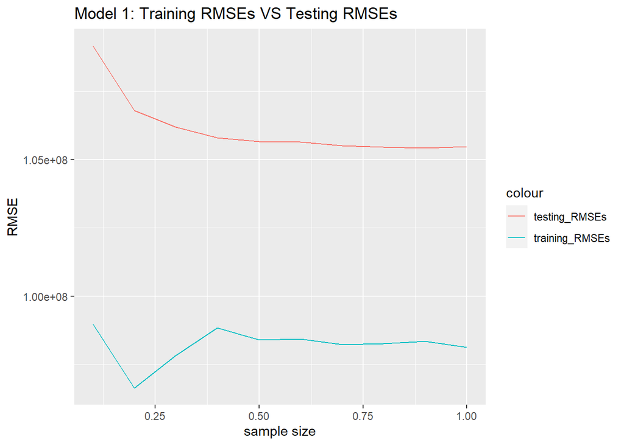

```r
ggplot(results, aes(sample_size)) +
  geom_line(aes(y=training_RMSEs, x=sample_size, colour="training_RMSEs")) +
  geom_line(aes(y=testing_RMSEs, x=sample_size, colour="testing_RMSEs")) +
  xlab("sample size") +
  ylab("RMSE") + labs(title="Model 1: Training RMSEs VS Testing RMSEs")
```

Numeric variables used: “Gross”, “Runtime”, “imdbRating”, “imdbVotes”, “tomatoRating”, “tomatoReviews”, “tomatoFresh”, “Budget”

### 5.2. Model 2 - Feature transformations

Improve the prediction quality from **Model 1** as much as possible by adding feature transformations of the numeric variables. Explore both numeric transformations such as power transforms and non-numeric transformations of the numeric variables like binning.

```r
# Build & evaluate model 2 (transformed numeric variables only)
set.seed(42)
selected_features = c("Gross", "Runtime", "imdbRating", "imdbVotes", "tomatoRating", "tomatoReviews", "tomatoFresh", "Budget" )
df_selected = subset(df_movie_gross_release_match, select = selected_features)
df_selected = df_selected[sample(nrow(df_selected)), ]

testing = df_selected[1 : (dim(df_selected)[1] * 0.2), ]
training = df_selected[(dim(df_selected)[1] * 0.2) : dim(df_selected)[1], ]
testing1 = na.omit(testing)
training1 = na.omit(training)

# feature transformation
# log transform on budget
training1$LogBudget = log(training1$Budget)
testing1$LogBudget = log(testing1$Budget)
training1$LogimdbVotes = log(training1$imdbVotes)
testing1$LogimdbVotes = log(testing1$imdbVotes)

# binning on
training1$BintomatoRating = cut(training1$tomatoRating, 5, include.lowest = TRUE, labels = c(1, 2, 3, 4, 5))
testing1$BintomatoRating = cut(testing1$tomatoRating, 5, include.lowest = TRUE, labels = c(1, 2, 3, 4, 5))

sample_size = c(0.1, 0.2, 0.3, 0.4, 0.5, 0.6, 0.7, 0.8, 0.9, 1)

training_rmses = matrix(0, nrow=10, ncol=10)
testing_rmses = matrix(0, nrow=10, ncol=10)

# start evaluation
for (i in 1:10) {
  # shuffle training
  training1 = training1[sample(nrow(training1)), ]
  for (j in 1:10) {
    training_cur = training1[1:round(sample_size[j] * nrow(training1)), ]

    res = estimate(training_cur, testing1)
    training_rmses[i, j] = res[[1]]
    testing_rmses[i, j] = res[[2]]
  }
}

# plot results
training_rmses = colMeans(training_rmses)
testing_rmses = colMeans(testing_rmses)

results = data.frame(cbind(sample_size, training_rmses, testing_rmses))
colnames(results) <- c("sample_size", "training_RMSEs", "testing_RMSEs")
print(min(testing_rmses))
```

```
## [1] 103683777
```

```r
print(which.min(testing_rmses))
```

```
## [1] 9
```

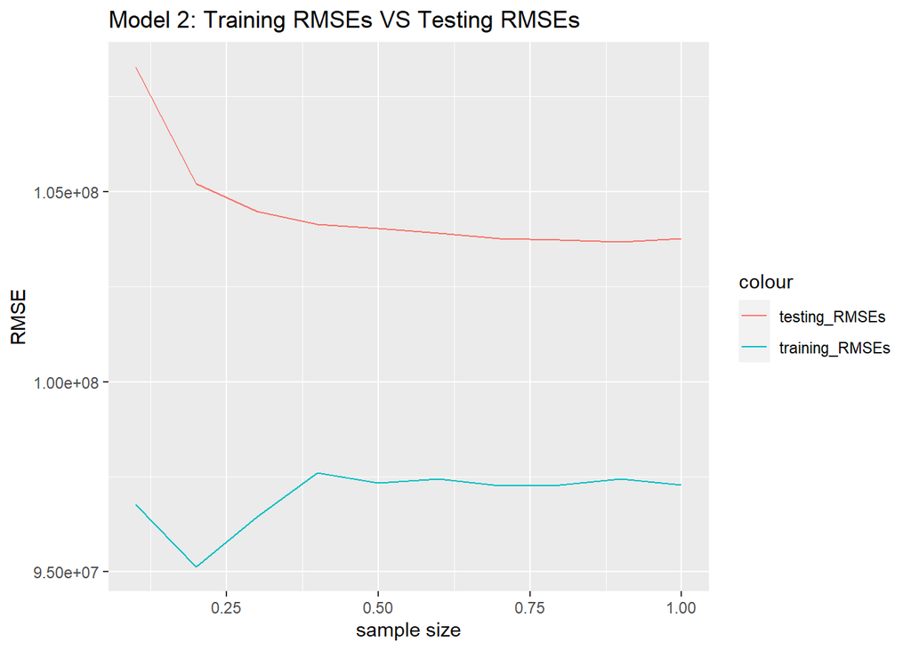

```r
ggplot(results, aes(sample_size)) +
  geom_line(aes(y=training_RMSEs, x=sample_size, colour="training_RMSEs")) +
  geom_line(aes(y=testing_RMSEs, x=sample_size, colour="testing_RMSEs")) +
  xlab("sample size") +
  ylab("RMSE") + labs(title="Model 2: Training RMSEs VS Testing RMSEs")
```

A log tranform was used for budget and imdbVotes and binning for tomatoRating. The scales of budget and imdbVotes are large compare with other variables, log transform can make the scales of budget and imdbvotes comparable with other variables. The binning on tomatoRating seems make the variable more discriminative, bining on other variables does not improve the performance.

### 5.3. Model 3 - Non-numeric variables

Convert genre, actors, directors, and other categorical variables to columns that can be used for regression. Process variables such as awards into more useful columns. Build a new model using these converted columns.

```r
# TODO: Build & evaluate model 3 (converted non-numeric variables only)

set.seed(42)
selected_features = c("Gross", "Genre", "Awards")
df_selected = subset(df_movie_gross_release_match, select = selected_features)
df_selected = df_selected[sample(nrow(df_selected)), ]

# transform binary genre variable
genre_df = data.frame(df_selected$Genre)
all_genre = apply(genre_df, 2, paste, collapse = ', ')
genre_dic_temp = unique(unlist(strsplit(all_genre, ', ')))
genre_dic = genre_dic_temp[genre_dic_temp!='N/A']
binary_genre = data.frame(matrix(0, nrow = length(df_selected$Genre), ncol = length(genre_dic)))
colnames(binary_genre) = genre_dic

for (i in 1:length(df_selected$Genre)){
  gener_i = df_selected$Genre[i]
  if(i%%10000 == 0)  print(gener_i)

  for (j in 1:length(genre_dic)){
    if(grepl(genre_dic[j], gener_i) == TRUE){
      binary_genre[i,j] = 1
    }
  }
}

df_selected = cbind(df_selected, binary_genre)
df_selected$Genre = NULL

# process Awards
df_selected$wins = as.numeric(str_extract(string = df_selected$Awards, "\\d+\\b(?=\\swin)"))
df_selected$wins[is.na(df_selected$wins)] = 0
# "Won {number}"
won = as.numeric(str_extract(string = df_selected$Awards, "(?<=Won\\s)\\d+"))
won[is.na(won)] = 0
df_selected$wins = df_selected$wins + won

# "{number} nominations"
df_selected$nominations = as.numeric(str_extract(string = df_selected$Awards, "\\d+\\b(?=\\snomination)"))
df_selected$nominations[is.na(df_selected$nominations)] = 0
# "Nominated for {number}"
nominated = as.numeric(str_extract(string = df_selected$Awards, "(?<=Nominated for\\s)\\d+"))
nominated[is.na(nominated)] = 0
df_selected$nominations = df_selected$nominations + nominated
df_selected$Awards = NULL

testing = df_selected[1 : (dim(df_selected)[1] * 0.2), ]
training = df_selected[(dim(df_selected)[1] * 0.2) : dim(df_selected)[1], ]
testing1 = na.omit(testing)
training1 = na.omit(training)

sample_size = c(0.1, 0.2, 0.3, 0.4, 0.5, 0.6, 0.7, 0.8, 0.9, 1)

training_rmses = matrix(0, nrow=10, ncol=10)
testing_rmses = matrix(0, nrow=10, ncol=10)

# start evaluation
for (i in 1:10) {
  # shuffle training
  training1 = training1[sample(nrow(training1)), ]
  for (j in 1:10) {
    # print((i-1)*10 + j)
    training_cur = training1[1:round(sample_size[j] * nrow(training1)), ]
    # print(summary(training_cur$tomatoFresh))
    # print(summary(testing1$tomatoFresh))

    res = estimate(training_cur, testing1)
    training_rmses[i, j] = res[[1]]
    testing_rmses[i, j] = res[[2]]
  }
}

# plot results
training_rmses = colMeans(training_rmses)
testing_rmses = colMeans(testing_rmses)

results = data.frame(cbind(sample_size, training_rmses, testing_rmses))
colnames(results) <- c("sample_size", "training_RMSEs", "testing_RMSEs")
print(min(testing_rmses))
```

```
## [1] 152790947
```

```r
print(which.min(testing_rmses))
```

```
## [1] 10
```

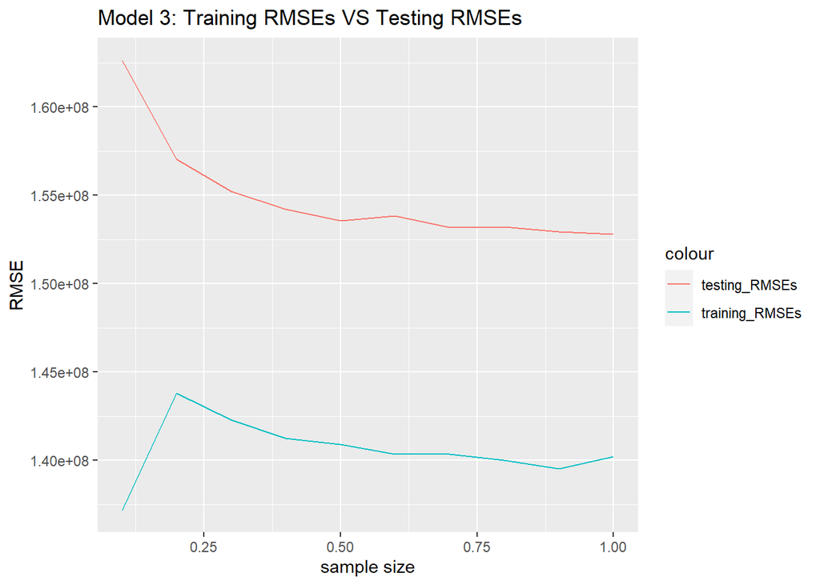

```r
ggplot(results, aes(sample_size)) +
  geom_line(aes(y=training_RMSEs, x=sample_size, colour="training_RMSEs")) +
  geom_line(aes(y=testing_RMSEs, x=sample_size, colour="testing_RMSEs")) +
  xlab("sample size") +
  ylab("RMSE") + labs(title="Model 3: Training RMSEs VS Testing RMSEs")
```

## 5.4. Model 4 - Numeric and categorical variables

Improve the prediction quality as much as possible by using both numeric and non-numeric variables from **Model 2 & 3**.

```r
# Build & evaluate model 4 (numeric & converted non-numeric variables)
set.seed(42)
selected_features = c("Gross", "Runtime", "imdbRating", "imdbVotes", "tomatoRating", "tomatoReviews", "tomatoFresh", "Budget", "Genre")
df_selected = subset(df_movie_gross_release_match, select = selected_features)
df_selected = df_selected[sample(nrow(df_selected)), ]

# convert non-numeric variables
# transform binary genre variable
genre_df = data.frame(df_selected$Genre)
all_genre = apply(genre_df, 2, paste, collapse = ', ')
genre_dic_temp = unique(unlist(strsplit(all_genre, ', ')))
genre_dic = genre_dic_temp[genre_dic_temp!='N/A']
binary_genre = data.frame(matrix(0, nrow = length(df_selected$Genre), ncol = length(genre_dic)))
colnames(binary_genre) = genre_dic

for (i in 1:length(df_selected$Genre)){
  gener_i = df_selected$Genre[i]
  if(i%%10000 == 0)  print(gener_i)

  for (j in 1:length(genre_dic)){
    if(grepl(genre_dic[j], gener_i) == TRUE){
      binary_genre[i,j] = 1
    }
  }
}

df_selected = cbind(df_selected, binary_genre)
df_selected$Genre = NULL


# numeric feature transform
testing = df_selected[1 : (dim(df_selected)[1] * 0.2), ]
training = df_selected[(dim(df_selected)[1] * 0.2) : dim(df_selected)[1], ]
testing1 = na.omit(testing)
training1 = na.omit(training)

# feature transformation
# log transform on budget
training1$LogBudget = log(training1$Budget)
testing1$LogBudget = log(testing1$Budget)
training1$LogimdbVotes = log(training1$imdbVotes)
testing1$LogimdbVotes = log(testing1$imdbVotes)

# binning on
training1$BintomatoRating = cut(training1$tomatoRating, 5, include.lowest = TRUE, labels = c(1, 2, 3, 4, 5))
testing1$BintomatoRating = cut(testing1$tomatoRating, 5, include.lowest = TRUE, labels = c(1, 2, 3, 4, 5))

# evaluation
testing = df_selected[1 : (dim(df_selected)[1] * 0.2), ]
training = df_selected[(dim(df_selected)[1] * 0.2) : dim(df_selected)[1], ]
testing1 = na.omit(testing)
training1 = na.omit(training)

sample_size = c(0.1, 0.2, 0.3, 0.4, 0.5, 0.6, 0.7, 0.8, 0.9, 1)

training_rmses = matrix(0, nrow=10, ncol=10)
testing_rmses = matrix(0, nrow=10, ncol=10)

# start evaluation
for (i in 1:10) {
  # shuffle training
  training1 = training1[sample(nrow(training1)), ]
  for (j in 1:10) {
    training_cur = training1[1:round(sample_size[j] * nrow(training1)), ]
    # print(summary(training_cur$tomatoFresh))
    # print(summary(testing1$tomatoFresh))

    res = estimate(training_cur, testing1)
    training_rmses[i, j] = res[[1]]
    testing_rmses[i, j] = res[[2]]
  }
}

# plot results
training_rmses = colMeans(training_rmses)
testing_rmses = colMeans(testing_rmses)

results = data.frame(cbind(sample_size, training_rmses, testing_rmses))
colnames(results) <- c("sample_size", "training_RMSEs", "testing_RMSEs")
print(min(testing_rmses))
```

```
## [1] 106094348
```

```r
print(which.min(testing_rmses))
```

```
## [1] 8
```

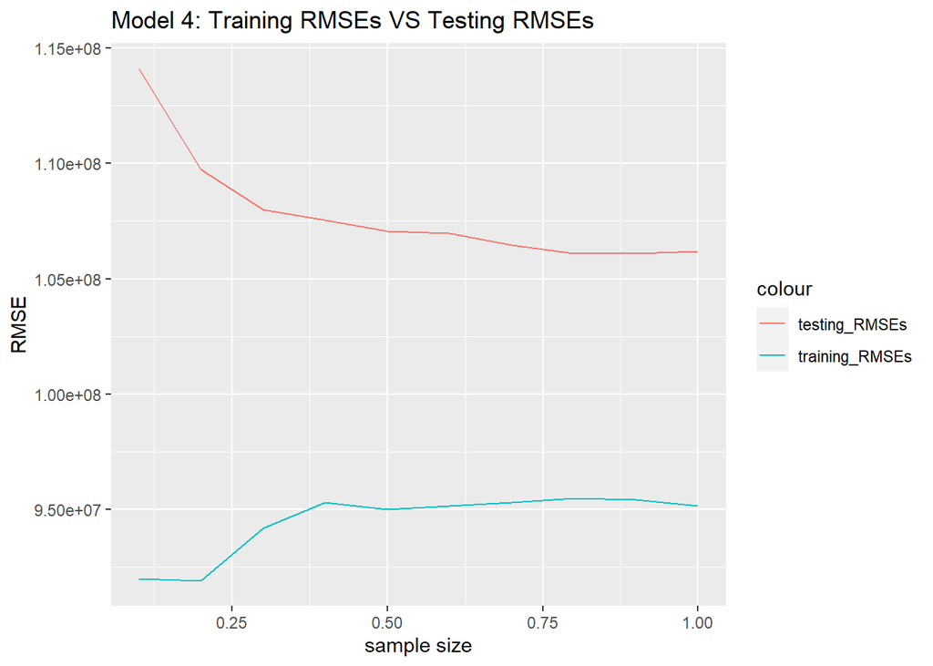

```r
ggplot(results, aes(sample_size)) +
  geom_line(aes(y=training_RMSEs, x=sample_size, colour="training_RMSEs")) +
  geom_line(aes(y=testing_RMSEs, x=sample_size, colour="testing_RMSEs")) +
  xlab("sample size") +
  ylab("RMSE") + labs(title="Model 4: Training RMSEs VS Testing RMSEs")
```

## 5.5. Model 5 - Additional features

Create additional features such as interactions or deeper analysis of complex variables tp build new model.

```r
#  Build & evaluate model 5 (numeric, non-numeric and additional features)
set.seed(42)
selected_features = c("Gross", "Runtime", "imdbRating", "imdbVotes", "tomatoRating", "tomatoReviews", "tomatoFresh", "Budget", "Genre", "Awards")
df_selected = subset(df_movie_gross_release_match, select = selected_features)
df_selected = df_selected[sample(nrow(df_selected)), ]

# convert non-numeric variables
# transform binary genre variable
genre_df = data.frame(df_selected$Genre)
all_genre = apply(genre_df, 2, paste, collapse = ', ')
genre_dic_temp = unique(unlist(strsplit(all_genre, ', ')))
genre_dic = genre_dic_temp[genre_dic_temp!='N/A']
binary_genre = data.frame(matrix(0, nrow = length(df_selected$Genre), ncol = length(genre_dic)))
colnames(binary_genre) = genre_dic

for (i in 1:length(df_selected$Genre)){
  gener_i = df_selected$Genre[i]
  if(i%%10000 == 0)  print(gener_i)

  for (j in 1:length(genre_dic)){
    if(grepl(genre_dic[j], gener_i) == TRUE){
      binary_genre[i,j] = 1
    }
  }
}

df_selected = cbind(df_selected, binary_genre)
df_selected$Genre = NULL

# process Awards
df_selected$wins = as.numeric(str_extract(string = df_selected$Awards, "\\d+\\b(?=\\swin)"))
df_selected$wins[is.na(df_selected$wins)] = 0
# "Won {number}"
won = as.numeric(str_extract(string = df_selected$Awards, "(?<=Won\\s)\\d+"))
won[is.na(won)] = 0
df_selected$wins = df_selected$wins + won

# "{number} nominations"
df_selected$nominations = as.numeric(str_extract(string = df_selected$Awards, "\\d+\\b(?=\\snomination)"))
df_selected$nominations[is.na(df_selected$nominations)] = 0
# "Nominated for {number}"
nominated = as.numeric(str_extract(string = df_selected$Awards, "(?<=Nominated for\\s)\\d+"))
nominated[is.na(nominated)] = 0
df_selected$nominations = df_selected$nominations + nominated
df_selected$Awards = NULL

# numeric feature transform
testing = df_selected[1 : (dim(df_selected)[1] * 0.2), ]
training = df_selected[(dim(df_selected)[1] * 0.2) : dim(df_selected)[1], ]
testing1 = na.omit(testing)
training1 = na.omit(training)

# feature transformation
# log transform on budget
training1$LogBudget = log(training1$Budget)
testing1$LogBudget = log(testing1$Budget)
training1$LogimdbVotes = log(training1$imdbVotes)
testing1$LogimdbVotes = log(testing1$imdbVotes)

# binning on
training1$BintomatoRating = cut(training1$tomatoRating, 5, include.lowest = TRUE, labels = c(1, 2, 3, 4, 5))
testing1$BintomatoRating = cut(testing1$tomatoRating, 5, include.lowest = TRUE, labels = c(1, 2, 3, 4, 5))

# add additional features
training1$is_budget_greater_than_3M <- ifelse(training1$Budget > 3000000, 1, 0)
testing1$is_budget_greater_than_3M <- ifelse(testing1$Budget > 3000000, 1, 0)
training1$is_imdbRating <- ifelse(training1$imdbRating > 6.5, 1, 0)
testing1$is_imdbRating <- ifelse(testing1$imdbRating > 6.5, 1, 0)

# evaluation
testing = df_selected[1 : (dim(df_selected)[1] * 0.2), ]
training = df_selected[(dim(df_selected)[1] * 0.2) : dim(df_selected)[1], ]
testing1 = na.omit(testing)
training1 = na.omit(training)

sample_size = c(0.1, 0.2, 0.3, 0.4, 0.5, 0.6, 0.7, 0.8, 0.9, 1)

training_rmses = matrix(0, nrow=10, ncol=10)
testing_rmses = matrix(0, nrow=10, ncol=10)

# start evaluation
for (i in 1:10) {
  # shuffle training
  training1 = training1[sample(nrow(training1)), ]
  for (j in 1:10) {
    training_cur = training1[1:round(sample_size[j] * nrow(training1)), ]
    # print(summary(training_cur$tomatoFresh))
    # print(summary(testing1$tomatoFresh))

    res = estimate(training_cur, testing1)
    training_rmses[i, j] = res[[1]]
    testing_rmses[i, j] = res[[2]]
  }
}

# plot results
training_rmses = colMeans(training_rmses)
testing_rmses = colMeans(testing_rmses)

results = data.frame(cbind(sample_size, training_rmses, testing_rmses))
colnames(results) <- c("sample_size", "training_RMSEs", "testing_RMSEs")
print(min(testing_rmses))
```

```
## [1] 106165837
```

```r
print(which.min(testing_rmses))
```

```
## [1] 9
```

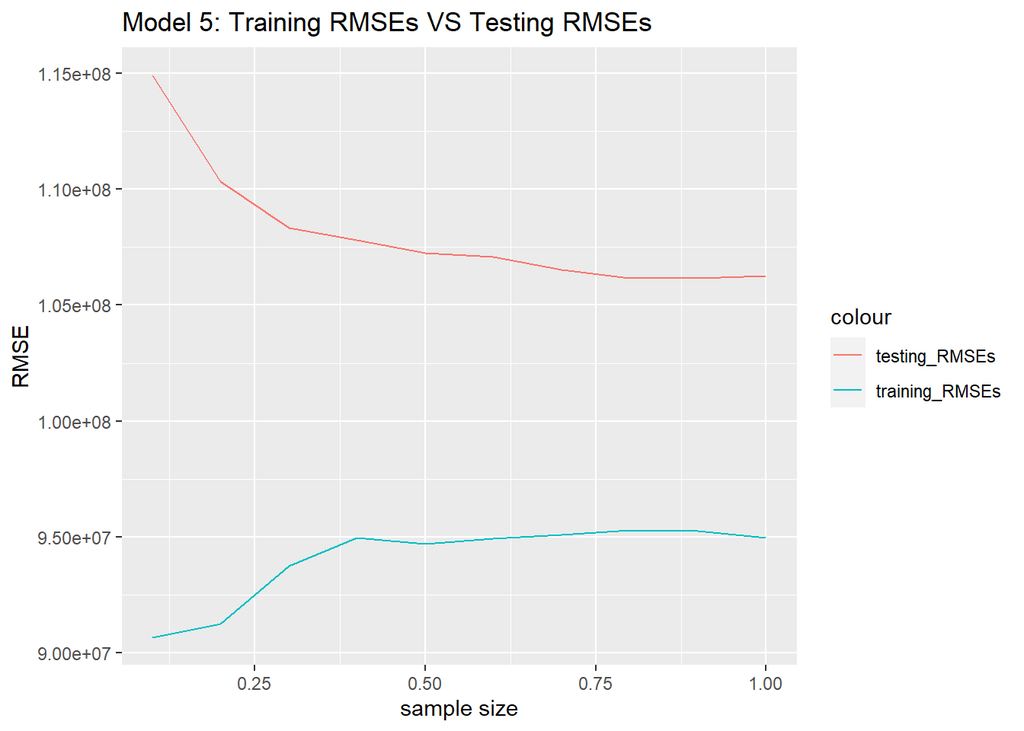

```r
ggplot(results, aes(sample_size)) +
  geom_line(aes(y=training_RMSEs, x=sample_size, colour="training_RMSEs")) +
  geom_line(aes(y=testing_RMSEs, x=sample_size, colour="testing_RMSEs")) +
  xlab("sample size") +
  ylab("RMSE") + labs(title="Model 5: Training RMSEs VS Testing RMSEs")
```

The final RMSE is 106165837